## The Model

### Model Overview

In the *Introduction to ID* app, you explored a simple 3-compartment model, the basic SIR model. The model for this app has a few additional compartments, which allows us to include more details/realism into our model. We again focus on tracking individuals with regard to their infection/disease status. For this model, we track the following compartments/stages:

- **S** - susceptible, uninfected individuals
- **P** - presymptomatic individuals who are infected and do not yet show symptoms. Those individuals can potentially be infectious.
- **A** - asymptomatic, infected individuals. Those individuals can potentially be infectious.
- **I** - individuals who are infected and show symptoms. Those individuals are likely infectious, but the model allows to adjust this, including no infectiousness.
- **R** - recovered/removed individuals. Those individuals have recovered and are immune.
- **D** - individuals who have died due to the disease.

Of course, as with the basic SIR model, we could include further details by extending the number of compartments. In general, for each additional feature you want to track, the existing number of compartments needs to be replicated by the discrete categories you have. For gender, one would need to have 2x the compartments. Similarly if one wanted to stratify according to young/medium/old age, 3x the compartments are required, etc.

In addition to specifying the *compartments* of a model, we need to specify the dynamics determining the changes for each compartment. In general, more compartments leads to more processes and more parameters governing these processes.

For this model, we include the following processes:

- Susceptible individuals (S) can become infected by pre-symptomatic (P), asymptomatic (A) or symptomatic (I) hosts. The rates at which infections from the different types of infected individuals (P, A and I) occur are governed by 3 parameters, *b<sub>P</sub>*, *b<sub>A</sub>*, and *b<sub>I</sub>*. In other words, those b<sub>i</sub> parameters determine how infectious an individual in stages P, A and I is.
- All infected individuals first enter the presymptomatic stage. They remain there for some time (determined by rate *g<sub>P</sub>*, the inverse of which is the average time spent in the presymptomatic stage). A fraction *f* of presymptomatic hosts move into the asymptomatic category, and the rest become symptomatic infected hosts.
- Asymptomatic infected hosts recover after some time (specified by the rate *g<sub>A</sub>*).
- Similarly, infected symptomatic hosts leave that stage at rate *g<sub>I</sub>*. For symptomatic hosts, two outcomes are possible, either recovery or death. The parameter *d* determines the fraction of hosts that die.
- Recovered individuals are immune to reinfection.

### Model Implementation

The flow diagram and the set of ordinary differential equations (ODE) which are used to implement this model are as follows:

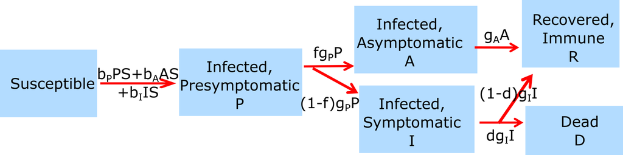

Flow diagram for this model.

$$\dot S = -S (b_P P + b_A A + b_I I)$$
$$\dot P = S (b_P P + b_A A + b_I I) - g_P P$$
$$\dot A = f g_P P - g_A A$$
$$\dot I = (1-f) g_P P - g_I I$$
$$\dot R = g_A A + (1-d) g_I I$$
$$\dot D = d g_I I$$